# chap2_exploring_ggplot2.R

hahsler

2020-06-19

This is additional code related to chapter 2 of *“Introduction to Data Mining”* by Pang-Ning Tan, Michael Steinbach and Vipin Kumar. **See [table of contents](https://github.com/mhahsler/Introduction_to_Data_Mining_R_Examples#readme) for code examples for other chapters.**

This work is licensed under the [Creative Commons Attribution 4.0 International License](http://creativecommons.org/licenses/by/4.0/). For questions please contact [Michael Hahsler](http://michael.hahsler.net).

```r
library(tidyverse)
```

```r
library(ggplot2)
```

Load the iris data set

```r
data(iris)
iris <- as_tibble(iris)

iris
```

```
## # A tibble: 150 x 5
##    Sepal.Length Sepal.Width Petal.Length Petal.Width Species
##           <dbl>       <dbl>        <dbl>       <dbl> <fct>
##  1          5.1         3.5          1.4         0.2 setosa
##  2          4.9         3            1.4         0.2 setosa
##  3          4.7         3.2          1.3         0.2 setosa
##  4          4.6         3.1          1.5         0.2 setosa
##  5          5           3.6          1.4         0.2 setosa
##  6          5.4         3.9          1.7         0.4 setosa
##  7          4.6         3.4          1.4         0.3 setosa
##  8          5           3.4          1.5         0.2 setosa
##  9          4.4         2.9          1.4         0.2 setosa
## 10          4.9         3.1          1.5         0.1 setosa
## # … with 140 more rows
```

# Basic statistics

Get summary statistics

```r
summary(iris)
```

```
##   Sepal.Length    Sepal.Width     Petal.Length    Petal.Width
##  Min.   :4.300   Min.   :2.000   Min.   :1.000   Min.   :0.100
##  1st Qu.:5.100   1st Qu.:2.800   1st Qu.:1.600   1st Qu.:0.300
##  Median :5.800   Median :3.000   Median :4.350   Median :1.300
##  Mean   :5.843   Mean   :3.057   Mean   :3.758   Mean   :1.199
##  3rd Qu.:6.400   3rd Qu.:3.300   3rd Qu.:5.100   3rd Qu.:1.800
##  Max.   :7.900   Max.   :4.400   Max.   :6.900   Max.   :2.500
##        Species
##  setosa    :50
##  versicolor:50
##  virginica :50
##
##
##
```

Get mean and standard deviation for sepal length

```r
iris %>% pull(Sepal.Length) %>% mean()
```

```
## [1] 5.843333
```

```r
iris %>% pull(Sepal.Length) %>% sd()
```

```
## [1] 0.8280661
```

Ignore missing values (Note: this data does not contain any, but this is what you would do)

```r
iris %>% pull(Sepal.Length) %>% mean(na.rm = TRUE)
```

```
## [1] 5.843333
```

Robust mean (trim 10% of observations from each end of the distribution)

```r
iris %>% pull(Sepal.Length) %>% mean(trim = .1)
```

```
## [1] 5.808333
```

Calculate a summary for all numeric columns

```r
iris %>% summarize_if(is.numeric, mean)
```

```
## # A tibble: 1 x 4
##   Sepal.Length Sepal.Width Petal.Length Petal.Width
##          <dbl>       <dbl>        <dbl>       <dbl>
## 1         5.84        3.06         3.76        1.20
```

```r
iris %>% summarize_if(is.numeric, median)
```

```
## # A tibble: 1 x 4
##   Sepal.Length Sepal.Width Petal.Length Petal.Width
##          <dbl>       <dbl>        <dbl>       <dbl>
## 1          5.8           3         4.35         1.3
```

```r
iris %>% summarize_if(is.numeric, sd)
```

```
## # A tibble: 1 x 4
##   Sepal.Length Sepal.Width Petal.Length Petal.Width
##          <dbl>       <dbl>        <dbl>       <dbl>
## 1        0.828       0.436         1.77       0.762
```

```r
iris %>% summarize_if(is.numeric, var)
```

```
## # A tibble: 1 x 4
##   Sepal.Length Sepal.Width Petal.Length Petal.Width
##          <dbl>       <dbl>        <dbl>       <dbl>
## 1        0.686       0.190         3.12       0.581
```

```r
iris %>% summarize_if(is.numeric, min)
```

```
## # A tibble: 1 x 4
##   Sepal.Length Sepal.Width Petal.Length Petal.Width
##          <dbl>       <dbl>        <dbl>       <dbl>
## 1          4.3           2            1         0.1
```

```r
iris %>% summarize_if(is.numeric, max)
```

```
## # A tibble: 1 x 4
##   Sepal.Length Sepal.Width Petal.Length Petal.Width
##          <dbl>       <dbl>        <dbl>       <dbl>
## 1          7.9         4.4          6.9         2.5
```

MAD (median absolute deviation)

```r
iris %>% summarize_if(is.numeric, mad)
```

```
## # A tibble: 1 x 4
##   Sepal.Length Sepal.Width Petal.Length Petal.Width
##          <dbl>       <dbl>        <dbl>       <dbl>
## 1         1.04       0.445         1.85        1.04
```

# Tabulate data

Count the different species.

```r
iris %>% count(Species)
```

```
## # A tibble: 3 x 2
##   Species        n
##   <fct>      <int>
## 1 setosa        50
## 2 versicolor    50
## 3 virginica     50
```

Discretize the data first since there are too many values (cut divides the range by breaks, see package discretization for other methods)

```r
iris_discrete <- iris %>% mutate_if(is.numeric,
  function(x) cut(x, 3, labels = c("short", "medium", "long"), ordered = TRUE))

iris_discrete
```

```
## # A tibble: 150 x 5
##    Sepal.Length Sepal.Width Petal.Length Petal.Width Species
##    <ord>        <ord>       <ord>        <ord>       <fct>
##  1 short        medium      short        short       setosa
##  2 short        medium      short        short       setosa
##  3 short        medium      short        short       setosa
##  4 short        medium      short        short       setosa
##  5 short        medium      short        short       setosa
##  6 short        long        short        short       setosa
##  7 short        medium      short        short       setosa
##  8 short        medium      short        short       setosa
##  9 short        medium      short        short       setosa
## 10 short        medium      short        short       setosa
## # … with 140 more rows
```

```r
summary(iris_discrete)
```

```
##  Sepal.Length Sepal.Width Petal.Length Petal.Width       Species
##  short :59    short :47   short :50    short :50   setosa    :50
##  medium:71    medium:88   medium:54    medium:54   versicolor:50
##  long  :20    long  :15   long  :46    long  :46   virginica :50
```

Create some tables (creating tables is a little harder using tidyverse)

```r
iris_discrete %>% select(Sepal.Length, Sepal.Width) %>% table()
```

```
##             Sepal.Width
## Sepal.Length short medium long
##       short     12     37   10
##       medium    31     37    3
##       long       4     14    2
```

```r
iris_discrete %>% select(Petal.Length, Petal.Width) %>% table()
```

```
##             Petal.Width
## Petal.Length short medium long
##       short     50      0    0
##       medium     0     48    6
##       long       0      6   40
```

```r
iris_discrete %>% select(Petal.Length, Species) %>% table()
```

```
##             Species
## Petal.Length setosa versicolor virginica
##       short      50          0         0
##       medium      0         48         6
##       long        0          2        44
```

```r
#table(iris_discrete)
```

Test if the two features are independent given the counts in the contingency table (H0: independence)

p-value: the probability of seeing a more extreme value of the test statistic under the assumption that H0 is correct. Low p-values (typically less than .05 or .01) indicate that H0 should be rejected.

```r
tbl <- iris_discrete %>% select(Sepal.Length, Sepal.Width) %>% table()
tbl
```

```
##             Sepal.Width
## Sepal.Length short medium long
##       short     12     37   10
##       medium    31     37    3
##       long       4     14    2
```

```r
chisq.test(tbl)
```

```
##
##  Pearson's Chi-squared test
##
## data:  tbl
## X-squared = 12.879, df = 4, p-value = 0.01188
```

Fisher’s exact test is better for small counts (cells with counts <5)

```r
fisher.test(tbl)
```

```
##
##  Fisher's Exact Test for Count Data
##
## data:  tbl
## p-value = 0.01063
## alternative hypothesis: two.sided
```

Plot the distribution for a discrete variable

```r
iris_discrete %>% pull(Sepal.Length) %>% table()
```

```
## .
##  short medium   long
##     59     71     20
```

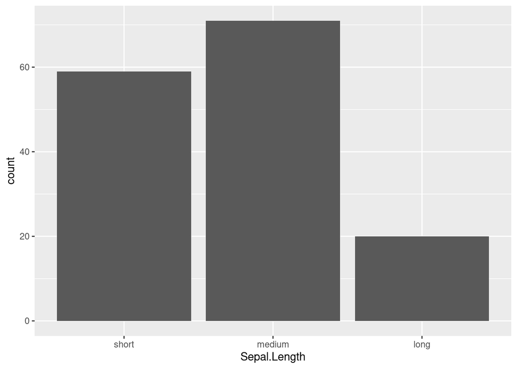

```r
ggplot(iris_discrete, aes(Sepal.Length)) + geom_bar()
```

# Percentiles

```r
iris %>% pull(Petal.Length) %>% quantile()
```

```
##   0%  25%  50%  75% 100%
## 1.00 1.60 4.35 5.10 6.90
```

Interquartile range

```r
quart <- iris %>% pull(Petal.Length) %>% quantile()
quart[4] - quart[2]
```

```
## 75%
## 3.5
```

# Visualizations

### Histogram

Show the distribution of a single numeric variable

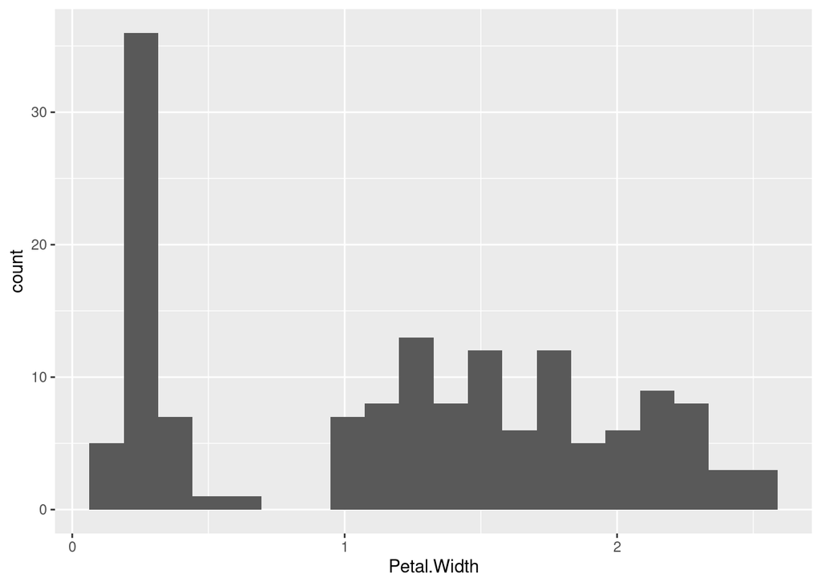

```r
ggplot(iris, aes(Petal.Width)) + geom_histogram(bins = 20)
```

### Scatter plot

Show the relationship between two numeric variables

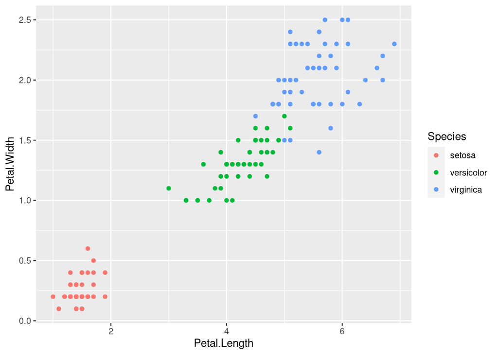

```r
ggplot(iris, aes(x = Petal.Length, y = Petal.Width, color = Species)) + geom_point()
```

### Scatter plot matrix

Show the relationship between several numeric variables

```r
library("GGally")
```

[figure not shown]

```r
ggpairs(iris,  aes(color=Species))
```

### Boxplot

Compare the distribution of several continuous variables

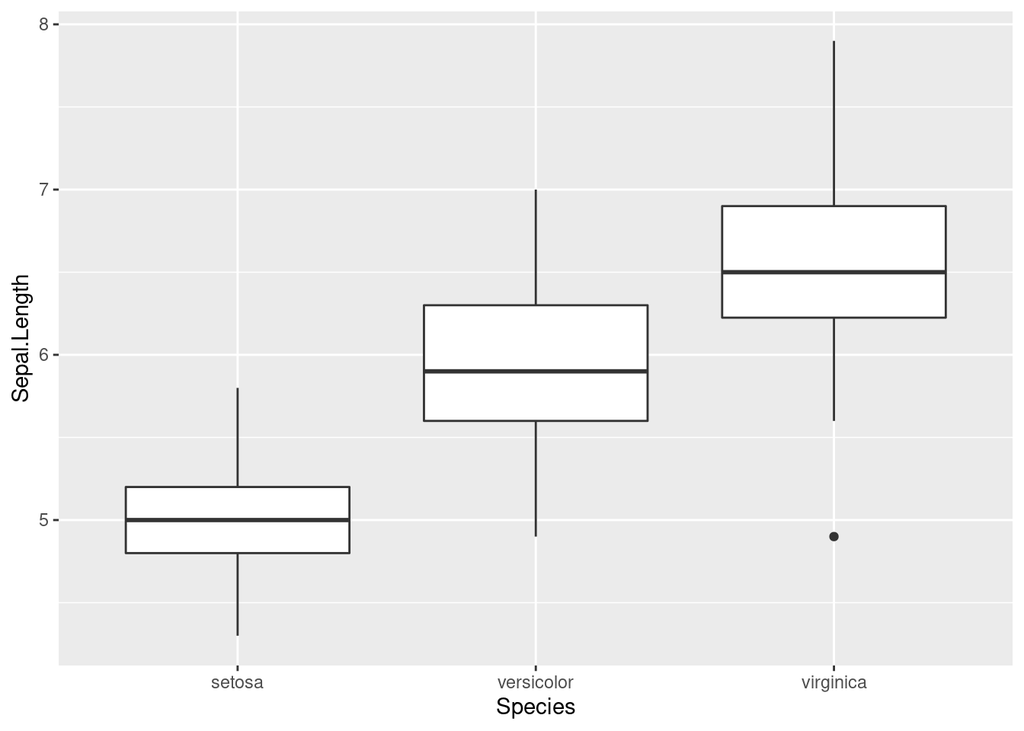

```r
ggplot(iris, aes(Species, Sepal.Length)) + geom_boxplot()
```

Group-wise averages

```r
iris %>% group_by(Species) %>% summarize_if(is.numeric, mean)
```

```
## # A tibble: 3 x 5
##   Species    Sepal.Length Sepal.Width Petal.Length Petal.Width
##   <fct>             <dbl>       <dbl>        <dbl>       <dbl>
## 1 setosa             5.01        3.43         1.46       0.246
## 2 versicolor         5.94        2.77         4.26       1.33
## 3 virginica          6.59        2.97         5.55       2.03
```

### ECDF: Empirical Cumulative Distribution Function

```r
e <- iris %>% pull(Petal.Length) %>% ecdf()
e
```

```
## Empirical CDF
## Call: ecdf(.)
##  x[1:43] =      1,    1.1,    1.2,  ...,    6.7,    6.9
```

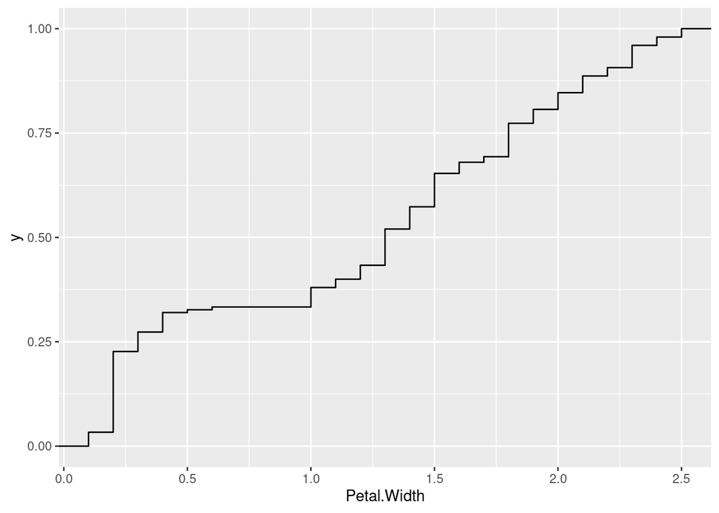

```r
ggplot(iris, aes(Petal.Width)) + stat_ecdf()
```

### Data matrix visualization

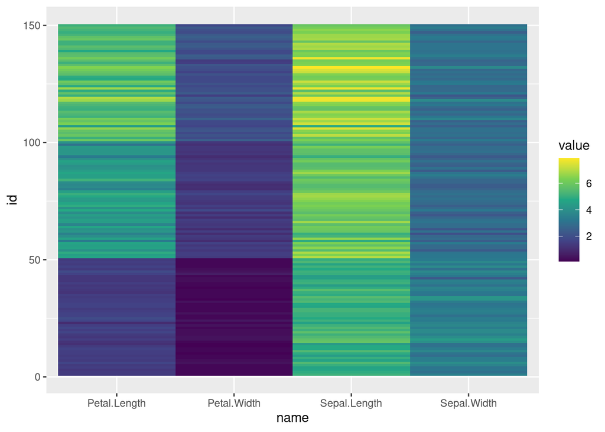

```r
ggplot(iris %>% mutate(id = row_number()) %>% pivot_longer(cols = 1:4),
  aes(x = name, y = id, fill = value)) + geom_tile() +
  scale_fill_viridis_c()
```

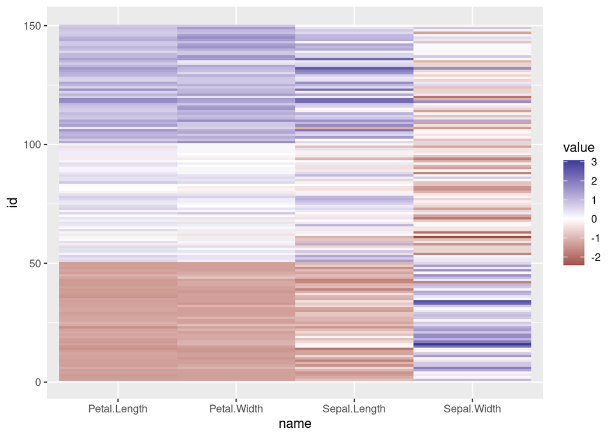

```r
iris_scaled <- scale(iris %>% select(-Species))

ggplot(as_tibble(iris_scaled) %>% mutate(id = row_number()) %>% pivot_longer(cols = 1:4),
  aes(x = name, y = id, fill = value)) + geom_tile() +
  scale_fill_gradient2()
```

Reorder

```r
library(seriation)
```

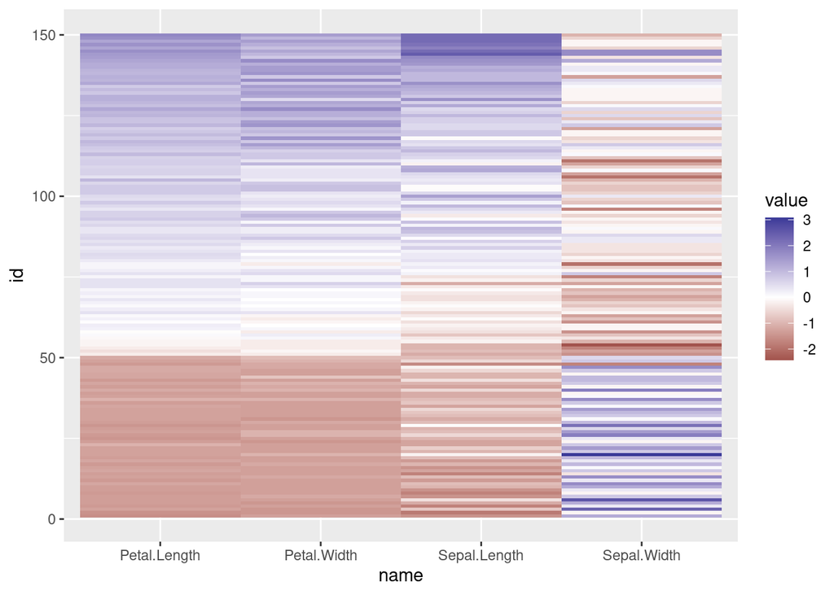

```r
o <- seriate(iris_scaled)
iris_ordered <- permute(iris_scaled, o)
ggplot(as_tibble(iris_ordered) %>% mutate(id = row_number()) %>% pivot_longer(cols = 1:4),
  aes(x = name, y = id, fill = value)) + geom_tile() +
  scale_fill_gradient2()
```

### Correlation matrix

Calculate and visualize the correlation between features

```r
cm1 <- iris %>% select(-Species) %>% as.matrix %>% cor()
cm1
```

```
##              Sepal.Length Sepal.Width Petal.Length Petal.Width
## Sepal.Length    1.0000000  -0.1175698    0.8717538   0.8179411
## Sepal.Width    -0.1175698   1.0000000   -0.4284401  -0.3661259
## Petal.Length    0.8717538  -0.4284401    1.0000000   0.9628654
## Petal.Width     0.8179411  -0.3661259    0.9628654   1.0000000
```

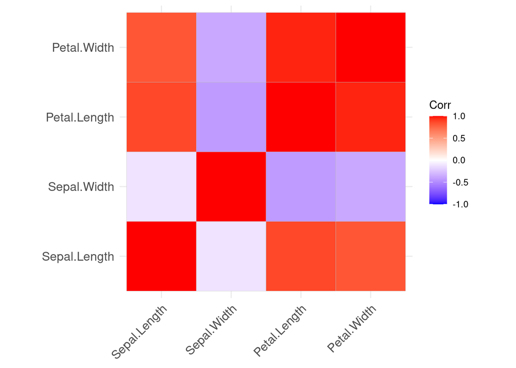

```r
library(ggcorrplot)
ggcorrplot(cm1)
```

use hmap from package seriation

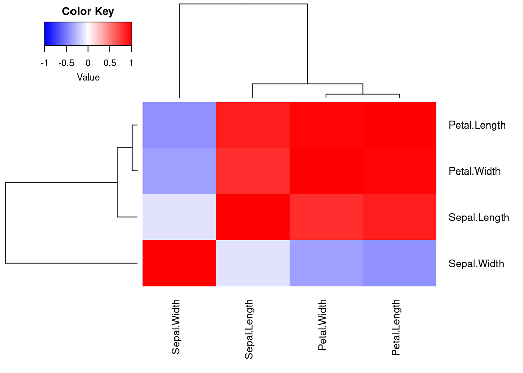

```r
hmap(cm1, margin = c(7,7), cexRow = 1, cexCol = 1)
```

Test if correlation is significantly different from 0

```r
cor.test(iris$Sepal.Length, iris$Sepal.Width)
```

```
##
##  Pearson's product-moment correlation
##
## data:  iris$Sepal.Length and iris$Sepal.Width
## t = -1.4403, df = 148, p-value = 0.1519
## alternative hypothesis: true correlation is not equal to 0
## 95 percent confidence interval:
##  -0.27269325  0.04351158
## sample estimates:
##        cor
## -0.1175698
```

```r
cor.test(iris$Petal.Length, iris$Petal.Width) #this one is significant
```

```
##
##  Pearson's product-moment correlation
##
## data:  iris$Petal.Length and iris$Petal.Width
## t = 43.387, df = 148, p-value < 2.2e-16
## alternative hypothesis: true correlation is not equal to 0
## 95 percent confidence interval:
##  0.9490525 0.9729853
## sample estimates:
##       cor
## 0.9628654
```

Correlation between objects

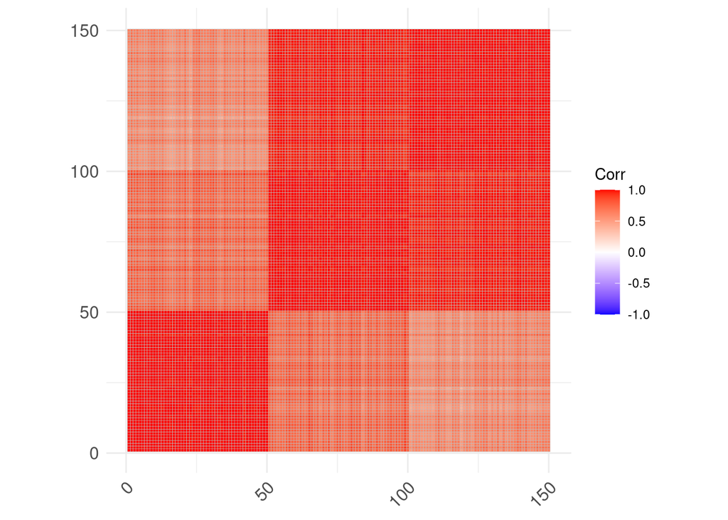

```r
cm2 <- iris %>% select(-Species) %>% as.matrix() %>% t() %>% cor()

ggcorrplot(cm2)
```

### Parallel coordinates plot

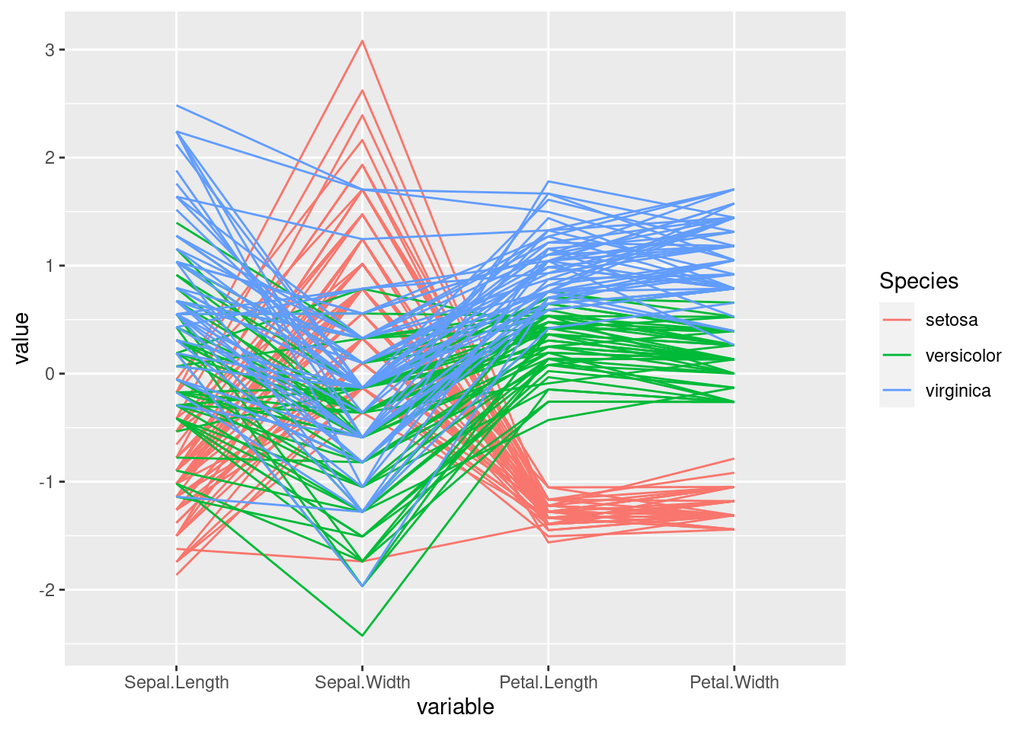

```r
library(GGally)
ggparcoord(as_tibble(iris), columns = 1:4, groupColumn = 5)
```

Reorder with placing correlated features next to each other

```r
library(seriation)
o <- seriate(as.dist(1-cor(iris[,1:4])), method="BBURCG")
get_order(o)
```

```
## [1] 3 4 1 2
```

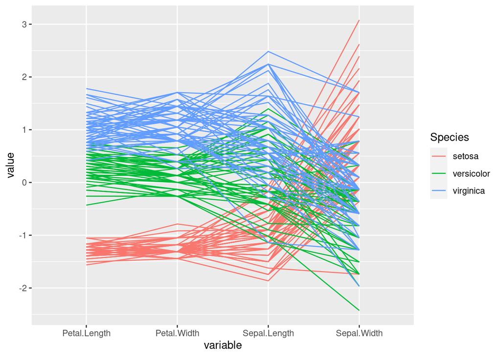

```r
ggparcoord(as_tibble(iris), columns = get_order(o), groupColumn = 5)
```

Look at https://www.r-graph-gallery.com/ for many example graphs.